# Detecting differential binding between CTCF mutated (H284N) cell lines and wild type: an analysis of ChIP-seq data using ‘csaw’ package

Kaiqiong Zhao

29 June 2021

# 1 Overview

```r
library(IRanges)
library(BiocGenerics)
library(GenomicAlignments)
library(GenomicRanges)
library(csaw)
library(edgeR)
library(Rsamtools)
library(TxDb.Hsapiens.UCSC.hg19.knownGene)
library(org.Hs.eg.db)
library(Gviz)
```

```r
dat_dir <- "/scratch/greenwood/kaiqiong.zhao/Michael_Witcher_KO_data/2021-01-KO-vs-WT-2021-06-KI/"
bam.files_KO =system(paste0("ls ",dat_dir, "Bam/KI/*", " | grep -v bai"), intern=T)
bam.files_WT =system(paste0("ls ",dat_dir, "Bam/WT/*", " | grep -v bai"), intern=T)

bam.files <- c(bam.files_KO, bam.files_WT)

#peak_files=system(paste0("ls ", dat_dir, "Bed/*.narrowPeak | grep -v KO |  grep -v WT-IP5"), intern=T)
#peak_files = peak_files[c(grep("KIKI-IP", peak_files), grep("WT", peak_files))]
```

```r
samples=gsub(".sorted.bam", "",basename(bam.files))
groups = c("KI", "KI", "KI", 'WT', "WT", "WT", "WT")
conditions = unique(groups)
pander::pander(cbind(samples))
```

| samples |
| --- |
| Input-KI |
| KI-IP2 |
| KI-IP3 |
| CTCF-0h-R1-S1 |
| CTCF-0h-R2-S6 |
| CTCF-0h-R3-S11 |
| CTCF-WT-1 |

The objective of this document was to determine the differential bindings, as a consequences of CTCF mutation.

# 2 Pre-processing checks

## 2.1 Examining mapping statistics

We check some mapping statistics for the dataset with *Rsamtools*.

```r
library(Rsamtools)
diagnostics <- list()
for (bam in bam.files) {
    total <- countBam(bam)$records
    mapped <- countBam(bam, param=ScanBamParam(
        flag=scanBamFlag(isUnmapped=FALSE)))$records
    marked <- countBam(bam, param=ScanBamParam(
        flag=scanBamFlag(isUnmapped=FALSE, isDuplicate=TRUE)))$records # the ducplicated record
    diagnostics[[basename(bam)]] <- c(Total=total, Mapped=mapped, Marked=marked)
}
diag.stats <- data.frame(do.call(rbind, diagnostics))
diag.stats$Prop.mapped <- diag.stats$Mapped/diag.stats$Total*100
diag.stats$Prop.marked <- diag.stats$Marked/diag.stats$Mapped*100
diag.stats
save(diag.stats, file="/scratch/greenwood/kaiqiong.zhao/kaiqiong.zhao/Projects/WitcherKI/Results/diag_stats.RData")
```

```r
load("/scratch/greenwood/kaiqiong.zhao/kaiqiong.zhao/Projects/WitcherKI/Results/diag_stats.RData")
diag.stats
```

```
##                              Total   Mapped Marked Prop.mapped Prop.marked
## Input-KI.sorted.bam       36372692 32943669      0    90.57253           0
## KI-IP2.sorted.bam         40510851 36753201      0    90.72434           0
## KI-IP3.sorted.bam         36603504 33021372      0    90.21369           0
## CTCF-0h-R1-S1.sorted.bam  12310508 12310508      0   100.00000           0
## CTCF-0h-R2-S6.sorted.bam  63520832 63315700      0    99.67706           0
## CTCF-0h-R3-S11.sorted.bam 67793739 67577402      0    99.68089           0
## CTCF-WT-1.sorted.bam      35370565 34904766      0    98.68309           0
```

‘Marked’ reads are the duplicated reads. Less marked reads stands for better quality. Seems like the duplicated reads have been already removed.

## 2.2 Obtaining the ENCODE blacklist for human genome

We first use the ENCODE blacklist to remove reads in problematic regions (such as centromeres, telomeres and satellite repeats), because these regions have been shown to often produce artifact signal. This is a standard QC step for functional genomics analysis.

```r
library(BiocFileCache)
bfc <- BiocFileCache("local", ask=FALSE)
black.path <- bfcrpath(bfc, file.path("https://www.encodeproject.org",
    "files/ENCFF419RSJ/@@download/ENCFF419RSJ.bed.gz"))

library(rtracklayer)
blacklist <- import(black.path)
blacklist
```

```
## GRanges object with 38 ranges and 0 metadata columns:
##        seqnames            ranges strand
##           <Rle>         <IRanges>  <Rle>
##    [1]    chr10 38528031-38529790      *
##    [2]    chr10 42070421-42070660      *
##    [3]    chr16 34571421-34571640      *
##    [4]    chr16 34572701-34572930      *
##    [5]    chr16 34584531-34584840      *
##    ...      ...               ...    ...
##   [34]     chr4 49118761-49119010      *
##   [35]     chr4 49120791-49121130      *
##   [36]     chr5 49601431-49602300      *
##   [37]     chr5 49657081-49657690      *
##   [38]     chr5 49661331-49661570      *
##   -------
##   seqinfo: 9 sequences from an unspecified genome; no seqlengths
```

## 2.3 Setting up the read extraction parameters

We set the minimum mapping quality score to 50 to remove poorly or non-uniquely aligned reads.

```r
library(csaw)
param <- readParam(minq=50, discard=blacklist)
param
```

```
##     Extracting reads in single-end mode
##     Duplicate removal is turned off
##     Minimum allowed mapping score is 50
##     Reads are extracted from both strands
##     No restrictions are placed on read extraction
##     Reads in 38 regions will be discarded
```

# 3 Computing the average fragment length

The average fragment length is estimated by maximizing the cross-correlation function. Generally, cross-correlations for TF datasets are sharper than for histone marks as the TFs typically contact a smaller genomic interval.

```r
max.delay = 500
x <- correlateReads(bam.files, param=reform(param, dedup=TRUE), max.dist = max.delay)
#x_KIKI <- correlateReads(bam.files[1:2], param=reform(param, dedup=TRUE), max.dist = max.delay)
#x_WT <- correlateReads(bam.files[3], param=reform(param, dedup=TRUE), max.dist = max.delay)
save(x, file="/scratch/greenwood/kaiqiong.zhao/kaiqiong.zhao/Projects/WitcherKI/Results/x_correlatedReads.RData")
```

```r
load("/scratch/greenwood/kaiqiong.zhao/kaiqiong.zhao/Projects/WitcherKI/Results/x_correlatedReads.RData")
frag.len <- maximizeCcf(x)
frag.len
```

```
## [1] 231
```

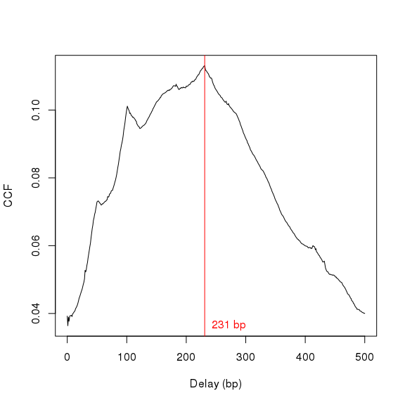

Figure 1: Cross-correlation function (CCF) against delay distance  
The delay with the maximum correlation is shown as the red line.

```r
plot(1:length(x)-1, x, xlab="Delay (bp)", ylab="CCF", type="l")
abline(v=frag.len, col="red")
text(x=frag.len, y=min(x), paste(frag.len, "bp"), pos=4, col="red")
```

# 4 Counting reads into windows

“Reads are then counted into sliding windows using *csaw* (Lun and Smyth 2015). For TF data analyses, smaller windows are necessary to capture sharp binding sites. In this case, a window size of 10 bp is used. The `windowCounts()` function produces a `RangedSummarizedExperiment` object containing a matrix of such counts. Each row corresponds to a window; each column represents a BAM file corresponding to a single sample”

```r
win.data <- windowCounts(bam.files, param= param, width=10, ext=frag.len)
save(win.data, file="/scratch/greenwood/kaiqiong.zhao/kaiqiong.zhao/Projects/WitcherKI/Results/win_data.RData")
```

```r
load("/scratch/greenwood/kaiqiong.zhao/kaiqiong.zhao/Projects/WitcherKI/Results/win_data.RData")
win.data
```

```
## class: RangedSummarizedExperiment
## dim: 50542930 7
## metadata(6): spacing width ... param final.ext
## assays(1): counts
## rownames: NULL
## rowData names(0):
## colnames: NULL
## colData names(4): bam.files totals ext rlen
```

“The default spacing of 50 bp is also used here. This may seem inappropriate given that the windows are only 10 bp. However, reads lying in the interval between adjacent windows will still be counted into several windows. This is because reads are extended to the value of `frag.len`, which is substantially larger than the 50 bp spacing.”

Smaller spacings can be used but will provide little benefit given that each extended read already overlaps multiple windows.

# 5 Filtering windows by abundance

Reads are counted into large bins and the median coverage across those bins is used as an estimate of the background abundance. This estimate is then compared to the average abundances of the windows, after rescaling to account for differences in the window and bin sizes. A window is only retained if its coverage is 3-fold higher than that of the background regions, i.e., the abundance of the window is greater than the background abundance estimate by log<sub>2</sub>(3) or more. This removes a large number of windows that are weakly or not marked and are likely to be irrelevant.

Large bins are necessary to obtain a precise estimate of background coverage, which would otherwise be too low in individual windows.

```r
bins <- windowCounts(bam.files, bin=TRUE, width=10000, param=param)
save(bins, file="/scratch/greenwood/kaiqiong.zhao/kaiqiong.zhao/Projects/WitcherKI/Results/bins.RData")
```

```r
#bins <- windowCounts(bam.files, bin=TRUE, width=10000, param=param)
load("/scratch/greenwood/kaiqiong.zhao/kaiqiong.zhao/Projects/WitcherKI/Results/bins.RData")
filter.stat <- filterWindowsGlobal(win.data, bins)
min.fc <- 3
keep <- filter.stat$filter > log2(min.fc)
summary(keep)
```

```
##     Mode    FALSE     TRUE
##  logical 50162600   380330
```

The effect of the fold-change threshold is examined visually in Figure 2. The chosen threshold is greater than the abundances of most bins in the genome – presumably, those that contain background regions. This suggests that the filter will remove most windows lying within background regions.

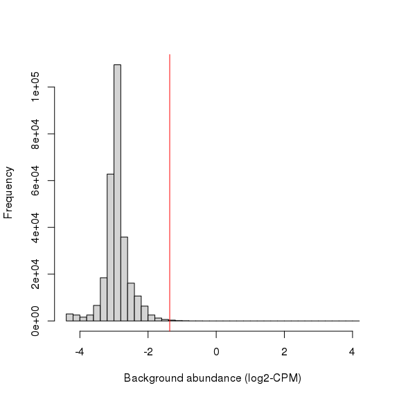

Figure 2: Histogram of average abundances across all 10 kbp genomic bins  
The filter threshold is shown as the red line.

```r
hist(filter.stat$back.abundances, main="", breaks=50,
    xlab="Background abundance (log2-CPM)")
threshold <- filter.stat$abundances[1] - filter.stat$filter[1] + log2(min.fc)
abline(v=threshold, col="red")
```

The actual filtering itself is done by simply subsetting the `RangedSummarizedExperiment` object.

```r
filtered.data <- win.data[keep,]
discard.data <- win.data[!keep,]
```

# 6 Normalizing for sample-specific trended biases

Normalization is required to eliminate confounding sample-specific biases prior to any comparisons between samples. Here, a trended bias is present between samples in Figure 3. This refers to a systematic fold-difference in per-window coverage between samples that changes according to the average abundance of the window.

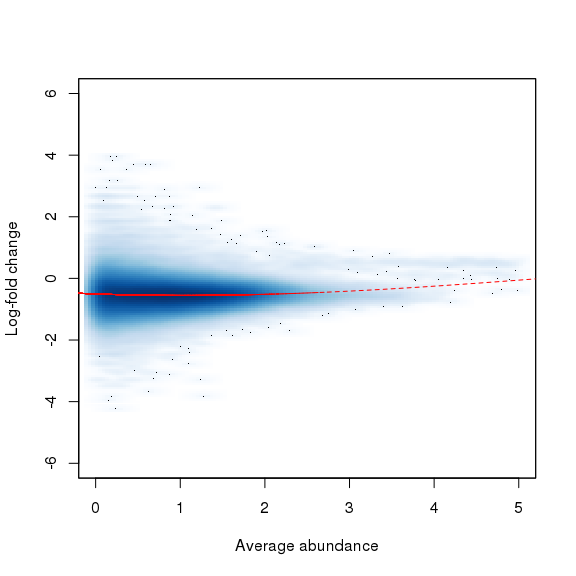

```r
win.ab <- scaledAverage(filtered.data)
adjc <- calculateCPM(filtered.data, use.offsets=FALSE)
logfc <- adjc[,2] - adjc[,3]
smoothScatter(win.ab, logfc, ylim=c(-6, 6), xlim=c(0, 5),
    xlab="Average abundance", ylab="Log-fold change")

lfit <- smooth.spline(logfc~win.ab, df=5)
o <- order(win.ab)
lines(win.ab[o], fitted(lfit)[o], col="red", lty=2)
```

Trended biases cannot be removed by scaling methods like TMM normalization (Robinson and Oshlack 2010), as the amount of scaling required varies with the abundance of the window. Rather, non-linear normalization methods must be used. *csaw* implements a version of the fast loess method (Ballman et al. 2004) that has been modified to handle count data (Lun and Smyth 2015). This produces a matrix of offsets that can be used during GLM fitting.

```r
filtered.data <- normOffsets(filtered.data)
offsets <- assay(filtered.data, "offset")
head(offsets)
```

```
##          [,1]     [,2]     [,3]     [,4]     [,5]     [,6]     [,7]
## [1,] 14.26125 17.47659 17.71344 18.31900 18.36102 18.11498 17.57386
## [2,] 13.91224 17.54469 17.69647 18.41409 18.45837 18.24120 17.55308
## [3,] 13.73831 17.58168 17.68308 18.46077 18.50704 18.31103 17.53823
## [4,] 13.61831 17.60771 17.67355 18.49281 18.54050 18.35980 17.52745
## [5,] 13.44922 17.64639 17.65953 18.53762 18.58757 18.42957 17.51024
## [6,] 13.37874 17.66321 17.65334 18.55625 18.60724 18.45922 17.50213
```

```r
#filtered <- normFactors(bins, se.out=filtered.data)
#(normfacs <- filtered.data$norm.factors)
#offsets <- normfacs
```

The effect of non-linear normalization is visualized with another mean-difference plot. Once the offsets are applied to adjust the log-fold changes, the trend is eliminated from the plot (Figure 4). The cloud of points is also centred at a log-fold change of zero. This indicates that normalization was successful in removing the differences between samples.

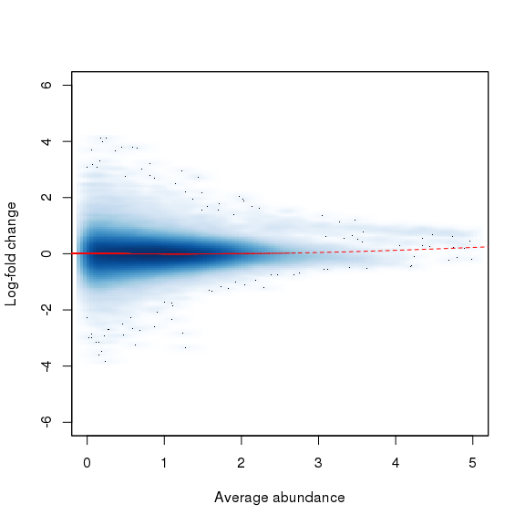

```r
norm.adjc <- calculateCPM(filtered.data, use.offsets=TRUE)
norm.fc <- norm.adjc[,2]-norm.adjc[,3]
smoothScatter(win.ab, norm.fc, ylim=c(-6, 6), xlim=c(0, 5),
    xlab="Average abundance", ylab="Log-fold change")

lfit <- smooth.spline(norm.fc~win.ab, df=5)
lines(win.ab[o], fitted(lfit)[o], col="red", lty=2)
```

# 7 Statistical modelling of biological variability

## 7.1 Setting up the design matrix

Counts for each window are modelled using *edgeR* as previously described (McCarthy, Chen, and Smyth 2012; Robinson, McCarthy, and Smyth 2010). We convert our `RangedSummarizedExperiment` object into a `DGEList`.

```r
library(edgeR)
y <- asDGEList(filtered.data)
summary(y)
```

```
##         Length  Class      Mode
## counts  2662310 -none-     numeric
## samples       3 data.frame list
## offset  2662310 -none-     numeric
```

```r
groups <- factor(groups)
design <- model.matrix(~0+groups)
colnames(design) <- levels(groups)
design
```

```
##   KI WT
## 1  1  0
## 2  1  0
## 3  1  0
## 4  0  1
## 5  0  1
## 6  0  1
## 7  0  1
## attr(,"assign")
## [1] 1 1
## attr(,"contrasts")
## attr(,"contrasts")$groups
## [1] "contr.treatment"
```

## 7.2 Estimating the NB dispersion

The `RangedSummarizedExperiment` object is coerced into a `DGEList` object (plus offsets) for use in *edgeR*. Estimation of the NB dispersion is performed using the `estimateDisp` function. Specifically, a NB dispersion trend is fitted to all windows against the average abundance. This means that empirical mean-dispersion trends can be flexibly modelled.

```r
y <- estimateDisp(y, design)
summary(y$trended.dispersion)
```

```
##    Min. 1st Qu.  Median    Mean 3rd Qu.    Max.
## 0.04175 0.05729 0.07132 0.06830 0.08095 0.20349
```

The NB dispersion trend is visualized in Figure 5 as the biological coefficient of variation (BCV), i.e., the square root of the NB dispersion. Note that only the trended dispersion will be used in the downstream steps – the common and tagwise values are only shown for diagnostic purposes. Specifically, the common BCV provides an overall measure of the variability in the data set, averaged across all windows. Data sets with common BCVs ranging from 10 to 20% are considered to have low variability, i.e., counts are highly reproducible. The tagwise BCVs should also be dispersed above and below the fitted trend, indicating that the fit was successful.

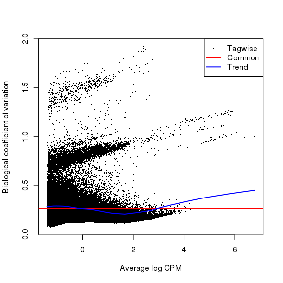

Figure 5: Abundance-dependent trend in the BCV for each window, represented by the blue line  
Common (red) and tagwise estimates (black) are also shown.

```r
plotBCV(y)
```

## 7.3 Estimating the QL dispersion

Additional modelling is provided with the QL methods in *edgeR* (Lund et al. 2012). This introduces a QL dispersion parameter for each window, which captures variability in the NB dispersion around the fitted trend for each window. Thus, the QL dispersion can model window-specific variability, whereas the NB dispersion trend is averaged across many windows. However, with limited replicates, there is not enough information for each window to stably estimate the QL dispersion. This is overcome by sharing information between windows with empirical Bayes (EB) shrinkage. The instability of the QL dispersion estimates is reduced by squeezing the estimates towards an abundance-dependent trend (Figure 6).

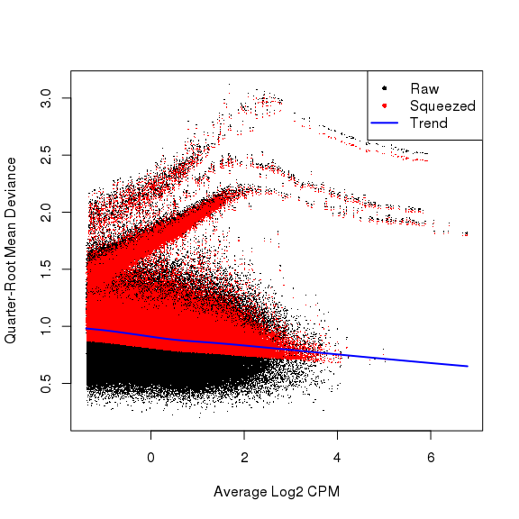

Figure 6: Effect of EB shrinkage on the raw QL dispersion estimate for each window (black) towards the abundance-dependent trend (blue) to obtain squeezed estimates (red)

```r
fit <- glmQLFit(y, design, robust=TRUE)
plotQLDisp(fit)
```

The extent of shrinkage is determined by the prior degrees of freedom (d.f.). Large prior d.f. indicates that the dispersions were similar across windows, such that strong shrinkage to the trend could be performed to increase stability and power. Small prior d.f. indicates that the dispersions were more variable. In such cases, less squeezing is performed as strong shrinkage would be inappropriate.

```r
summary(fit$df.prior)
```

```
##    Min. 1st Qu.  Median    Mean 3rd Qu.    Max.
##  0.2107  8.1679  8.1679  7.7984  8.1679  8.1679
```

Also note the use of `robust=TRUE` in the `glmQLFit()` call, which reduces the sensitivity of the EB procedures to outlier variances. This is particularly noticeable in Figure 6 with highly variable windows that (correctly) do not get squeezed towards the trend.

## 7.4 Examining the data with MDS plots

Multi-dimensional scaling (MDS) plots are used to examine the similarities between samples. The distance between a pair of samples on this plot represents the overall log-fold change between those samples. Ideally, replicates should cluster together while samples from different conditions should be separate. Samples of different cell types separate well in Figure 7, indicating that significant differences are likely to be present between cell types.

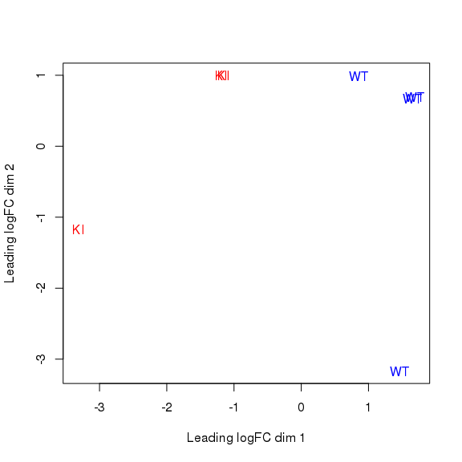

Figure 7: MDS plot with two dimensions for all samples  
Samples are labelled and coloured according to the experimental conditions. A larger top set of windows was used to improve the visualization of the genome-wide differences between the WT samples.

```r
plotMDS(cpm(y, log=TRUE), top=10000, labels=groups,
    col=c("red", "blue")[as.integer(groups)])
```

The presence of a large batch effect between replicates is not ideal. Nonetheless, we can still proceed with the DB analysis - albeit with some loss of power due to the inflated NB dispersions - given that there are strong differences between genotypes in Figure 7,

# 8 Testing for DB and controlling the FDR

## 8.1 Testing for DB with QL F-tests

DB windows are identified using the QL F-test. Windows are clustered into regions and the region-level FDR is controlled using Simes’ method (Simes 1986; Lun and Smyth 2014).

```r
contrast <- makeContrasts(KI-WT, levels=design)
res <- glmQLFTest(fit, contrast=contrast)
head(res$table)
```

```
##      logFC   logCPM        F      PValue
## 1 15.89237 2.787015 10.87551 0.070619326
## 2 17.60008 3.862116 12.07988 0.063797890
## 3 16.06030 4.406082 27.46056 0.002950685
## 4 16.03495 4.782758 27.07833 0.003045103
## 5 16.87486 5.314450 27.50198 0.002940698
## 6 17.23588 5.536280 27.56153 0.002926419
```

## 8.2 Controlling the FDR across regions

Aggregating windows into regions and combining the p-values. Here, adjacent windows less than 100 bp apart are aggregated into clusters. Each cluster represents a genomic region.

```r
merged <- mergeWindows(rowRanges(filtered.data), tol=100, max.width=5000)
tabcom <- combineTests(merged$id, res$table)
head(tabcom)
```

```
## DataFrame with 6 rows and 8 columns
##   num.tests num.up.logFC num.down.logFC      PValue         FDR   direction
##   <integer>    <integer>      <integer>   <numeric>   <numeric> <character>
## 1        62           33              0 0.006302558 0.031521648          up
## 2        62           23              0 0.009483936 0.040595249          up
## 3        11            0              9 0.032231172 0.092109160        down
## 4        10            0              8 0.033989193 0.095364934        down
## 5         6            4              0 0.014450915 0.053750356          up
## 6        10            0             10 0.000003169 0.000456346        down
##    rep.test rep.logFC
##   <integer> <numeric>
## 1        61 15.343969
## 2       113 14.563503
## 3       127 -1.653825
## 4       140 -0.920361
## 5       146  1.112567
## 6       157 -3.567906
```

```r
head(tabcom[ order(tabcom$FDR), ])
```

```
## DataFrame with 6 rows and 8 columns
##       num.tests num.up.logFC num.down.logFC      PValue         FDR   direction
##       <integer>    <integer>      <integer>   <numeric>   <numeric> <character>
## 4194         16            0             12 3.43042e-09 5.61502e-05        down
## 7962         11            0             11 3.09418e-09 5.61502e-05        down
## 29548        10            0             10 1.70407e-09 5.61502e-05        down
## 23698        10            0             10 5.24110e-09 6.43410e-05        down
## 21132        10            0             10 9.29620e-09 9.12980e-05        down
## 41635        11            0             11 1.50391e-08 1.23082e-04        down
##        rep.test rep.logFC
##       <integer> <numeric>
## 4194      35753  -5.37508
## 7962      65537  -4.72475
## 29548    232981  -4.89848
## 23698    188177  -4.24387
## 21132    168098  -4.32703
## 41635    323776  -3.14075
```

## 8.3 Examining the scope and direction of DB

```r
is.sig <- tabcom$FDR <= 0.05
summary(is.sig)
```

```
##    Mode   FALSE    TRUE
## logical   36380   12725
```

Determining the direction of DB is more complicated, as clusters may contain windows that are changing in opposite directions. One approach is to use the direction of DB from the windows that contribute most to the combined $p$-value, as reported in the `direction` field for each cluster. If significance is driven by windows changing in both directions, the direction for the cluster is defined as `"mixed"`. Otherwise, the reported direction is the same as that of the windows, i.e., `"up"` or `"down"`.

```r
table(tabcom$direction[is.sig])
```

```
##
##  down mixed    up
##  7487     3  5235
```

Another approach is to use the log-fold change of the most significant window (identified with the `getBestTest()` function) as a proxy for the log-fold change of the cluster.

```r
tabbest <- getBestTest(merged$id, res$table)
head(tabbest[order(tabbest$FDR),])
```

```
## DataFrame with 6 rows and 8 columns
##       num.tests num.up.logFC num.down.logFC      PValue         FDR   direction
##       <integer>    <integer>      <integer>   <numeric>   <numeric> <character>
## 4194         16            0             11 3.43042e-09 5.61502e-05        down
## 7962         11            0             11 3.09418e-09 5.61502e-05        down
## 29548        10            0             10 2.05110e-09 5.61502e-05        down
## 23698        10            0             10 5.24110e-09 6.43410e-05        down
## 21132        10            0             10 1.47930e-08 1.23082e-04        down
## 41635        11            0             11 1.50391e-08 1.23082e-04        down
##        rep.test rep.logFC
##       <integer> <numeric>
## 4194      35753  -5.37508
## 7962      65537  -4.72475
## 29548    232982  -5.12683
## 23698    188177  -4.24387
## 21132    168097  -4.27179
## 41635    323776  -3.14075
```

```r
is.sig.pos <- (tabbest$rep.logFC > 0)[is.sig]
summary(is.sig.pos)
```

```
##    Mode   FALSE    TRUE
## logical    7489    5236
```

This approach is generally satisfactory, though it will not capture multiple changes in opposite directions. It also tends to overstate the change in each cluster.

Try `mixedClusters()` to formally detect clusters that contain significant changes in both directions.

These results are saved to file, as previously described. Key objects are also saved for convenience.

## 8.4 Saving results to file

```r
out.ranges <- merged$region
mcols(out.ranges) <- data.frame(tabcom,
    best.pos=mid(ranges(rowRanges(filtered.data[tabbest$rep.test]))),
    best.logFC=tabbest$rep.logFC)
saveRDS(out.ranges, file = "/scratch/greenwood/kaiqiong.zhao/kaiqiong.zhao/Projects/WitcherKI/Results/out_ranges_June_28.rds")
#saveRDS( out.ranges,file="Results/CTCF_results.rds",)
```

# 9 Annotation and visualization

Annotation for each region is added using the `detailRanges` function, as previously described.

```r
library(TxDb.Hsapiens.UCSC.hg19.knownGene)
library(org.Hs.eg.db)
anno <- detailRanges(out.ranges, orgdb=org.Hs.eg.db,
    txdb=TxDb.Hsapiens.UCSC.hg19.knownGene)
mcols(out.ranges) <- cbind(mcols(out.ranges), anno)
```

One of the top-ranked DB regions will be visualized here. This corresponds to a simple DB event as all windows are changing in the same direction, i.e., up in the WT.

```r
o <- order(out.ranges$PValue)
cur.region <- out.ranges[o[1]]
cur.region
```

```
## GRanges object with 1 range and 13 metadata columns:
##       seqnames            ranges strand | num.tests num.up.logFC num.down.logFC
##          <Rle>         <IRanges>  <Rle> | <integer>    <integer>      <integer>
##   [1]    chr22 50585151-50585610      * |        10            0             10
##            PValue         FDR   direction  rep.test rep.logFC  best.pos
##         <numeric>   <numeric> <character> <integer> <numeric> <integer>
##   [1] 1.70407e-09 5.61502e-05        down    232981  -4.89848  50585405
##       best.logFC      overlap          left          right
##        <numeric>  <character>   <character>    <character>
##   [1]   -5.12683 MOV10L1:+:PE MOV10L1:+:912 MOV10L1:+:2208
##   -------
##   seqinfo: 24 sequences from an unspecified genome
```

We use *Gviz* (F. and R. 2016) to plot the results. We set up some tracks to display genome coordinates and gene annotation.

```r
library(Gviz)
gax <- GenomeAxisTrack(col="black", fontsize=15, size=2)
greg <- GeneRegionTrack(TxDb.Hsapiens.UCSC.hg19.knownGene, showId=TRUE,
    geneSymbol=TRUE, name="", background.title="transparent")
symbols <- unlist(mapIds(org.Hs.eg.db, gene(greg), "SYMBOL",
    "ENTREZID", multiVals = "first"))
symbol(greg) <- symbols[gene(greg)]
```

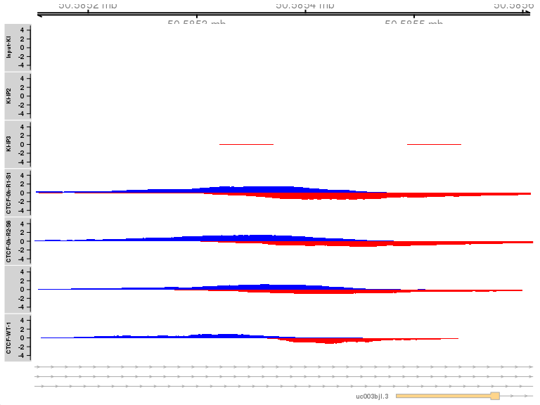

```r
library(Gviz)
collected <- list()
lib.sizes <- filtered.data$totals/1e6

for (i in 1:length(bam.files)) {
    reads <- extractReads(bam.file=bam.files[i], cur.region, param=param)
    pcov <- as(coverage(reads[strand(reads)=="+"])/lib.sizes[i], "GRanges")
    ncov <- as(coverage(reads[strand(reads)=="-"])/-lib.sizes[i], "GRanges")
    ptrack <- DataTrack(pcov, type="histogram", lwd=0, ylim=c(-5, 5),
        name=as.character(samples[i]), col.axis="black", col.title="black",
        fill="blue", col.histogram=NA)
    ntrack <- DataTrack(ncov, type="histogram", lwd=0, ylim=c(-5, 5),
        fill="red", col.histogram=NA)
    collected[[i]] <- OverlayTrack(trackList=list(ptrack, ntrack))
}

gax <- GenomeAxisTrack(col="black", fontsize=15, size=2)
greg <- GeneRegionTrack(TxDb.Hsapiens.UCSC.hg19.knownGene, showId=TRUE,
    geneSymbol=TRUE, name="", background.title="transparent")
plotTracks(c(gax, collected, greg), chromosome=as.character(seqnames(cur.region)),
    from=start(cur.region), to=end(cur.region))
```

# References

Ballman, K. V., D. E. Grill, A. L. Oberg, and T. M. Therneau. 2004. “Faster cyclic loess: normalizing RNA arrays via linear models.” *Bioinformatics* 20 (16): 2778–86.

F., Hahne, and Ivanek R. 2016. “Visualizing Genomic Data Using Gviz and Bioconductor.” In *Statistical Genomics: Methods and Protocols*, edited by Ewy Mathé and Sean Davis, 335–51. New York, NY: Springer New York. https://doi.org/10.1007/978-1-4939-3578-9_16.

Lun, A. T., and G. K. Smyth. 2014. “De novo detection of differentially bound regions for ChIP-seq data using peaks and windows: controlling error rates correctly.” *Nucleic Acids Res.* 42 (11): e95.

———. 2015. “csaw: a Bioconductor package for differential binding analysis of ChIP-seq data using sliding windows.” *Nucleic Acids Res.* https://doi.org/10.1093/nar/gkv1191.

Lund, S. P., D. Nettleton, D. J. McCarthy, and G. K. Smyth. 2012. “Detecting differential expression in RNA-sequence data using quasi-likelihood with shrunken dispersion estimates.” *Stat. Appl. Genet. Mol. Biol.* 11 (5): Article 8.

McCarthy, D. J., Y. Chen, and G. K. Smyth. 2012. “Differential expression analysis of multifactor RNA-Seq experiments with respect to biological variation.” *Nucleic Acids Res.* 40 (10): 4288–97.

Robinson, M. D., D. J. McCarthy, and G. K. Smyth. 2010. “edgeR: a Bioconductor package for differential expression analysis of digital gene expression data.” *Bioinformatics* 26 (1): 139–40.

Robinson, M. D., and A. Oshlack. 2010. “A scaling normalization method for differential expression analysis of RNA-seq data.” *Genome Biol.* 11 (3): R25.

Simes, R. J. 1986. “An Improved Bonferroni Procedure for Multiple Tests of Significance.” *Biometrika* 73 (3): 751–54.